# CHARITY PROJECT ASSIGNMENT - PART 1

### 1. Read data from csv file

1. Here I use the na.strings=“NA” argument to encode the missing values.
2. I set stringsAsFactors=TRUE
3. Finally, I use the colClasses argument to update DONR, HOME, and HINC from integers to factors.

```r
setwd('/Users/stevenfutter/Dropbox/NU/MACHINE_LEARNING/charity_project')
charity = read.csv('projectDataPart1.csv', header=T, na.strings="NA",
                   stringsAsFactors = TRUE,
                   colClasses=c("DONR"="factor", "HOME"="factor","HINC"="factor"))

# set up $ expansion
attach(charity)

# check that column types are set up correctly
str(charity)
```

```
## 'data.frame':    3684 obs. of  21 variables:
##  $ ID      : int  39 315 333 377 461 557 711 776 792 893 ...
##  $ DONR    : Factor w/ 1 level "1": 1 1 1 1 1 1 1 1 1 1 ...
##  $ DAMT    : num  20 5 10 5 10 25 15 30 10 36 ...
##  $ AGE     : int  43 85 24 76 83 43 87 77 40 76 ...
##  $ HOME    : Factor w/ 2 levels "0","1": 2 1 1 2 2 1 2 2 2 2 ...
##  $ HINC    : Factor w/ 7 levels "1","2","3","4",..: 6 1 6 7 1 NA 5 4 4 5 ...
##  $ GENDER  : Factor w/ 6 levels " ","A","F","J",..: 3 3 5 3 3 3 3 5 3 3 ...
##  $ MEDAGE  : int  46 42 38 42 40 29 42 42 50 48 ...
##  $ MEDPPH  : int  228 151 223 292 189 125 174 140 172 193 ...
##  $ MEDHVAL : int  3909 689 731 3359 1207 684 2907 1139 504 1178 ...
##  $ MEDINC  : int  870 235 350 878 284 272 420 303 238 482 ...
##  $ MEDEDUC : int  153 120 120 160 128 140 140 141 120 145 ...
##  $ NUMPROM : int  14 70 13 24 22 20 23 27 50 45 ...
##  $ NUMPRM12: int  12 10 8 15 12 10 12 10 13 14 ...
##  $ RAMNTALL: num  20 102 15 29 29 27 27 35 102 109 ...
##  $ NGIFTALL: int  1 21 1 5 4 2 3 2 12 7 ...
##  $ MAXRAMNT: num  20 8 15 10 11 20 15 20 11 23 ...
##  $ LASTGIFT: num  20 5 15 6 11 20 9 20 11 23 ...
##  $ TDON    : num  16 18 20 16 18 ...
##  $ RFA_97  : Factor w/ 14 levels "L1E","L1F","L1G",..: 2 7 2 12 8 2 5 2 4 9 ...
##  $ RFA_96  : Factor w/ 58 levels " ","A1D","A1E",..: 22 49 22 42 12 4 9 4 46 13 ...
```

```r
# confirm size of data table
dim(charity) # 3684 21
```

```
## [1] 3684   21
```

```r
# take a peek at the data
head(charity)
```

```
##    ID DONR DAMT AGE HOME HINC GENDER MEDAGE MEDPPH MEDHVAL MEDINC MEDEDUC
## 1  39    1   20  43    1    6      F     46    228    3909    870     153
## 2 315    1    5  85    0    1      F     42    151     689    235     120
## 3 333    1   10  24    0    6      M     38    223     731    350     120
## 4 377    1    5  76    1    7      F     42    292    3359    878     160
## 5 461    1   10  83    1    1      F     40    189    1207    284     128
## 6 557    1   25  43    0 <NA>      F     29    125     684    272     140
##   NUMPROM NUMPRM12 RAMNTALL NGIFTALL MAXRAMNT LASTGIFT TDON RFA_97 RFA_96
## 1      14       12       20        1       20       20   16    L1F    F1F
## 2      70       10      102       21        8        5   18    L3D    S3D
## 3      13        8       15        1       15       15   20    L1F    F1F
## 4      24       15       29        5       10        6   16    L4E    N4E
## 5      22       12       29        4       11       11   18    L3E    A3E
## 6      20       10       27        2       20       20   18    L1F    A1F
```

### 2. Data Quality Check

1. Let’s look at a quick summary of the values of the data to get a feel for the value ranges, shape of the distributions, and the number of missing values for each variable in the dataset. To do this we use R’s Hmisc library to describe the dataset, as below.

As can be seen in the output below MEDHVAL has suffers from skew since the mean and median numbers are quite different. Rather than use the numbers in the output below I provide a matrix of histograms to evaluate the output - see below. RAMNTALL, the dollar amount of lifetime gifts to date, has some extreme values. 290.8 is the 95% percentile value, but the highest values are 1190, 1610, 1622, 1765, and 2200.

```r
library(Hmisc)
Hmisc::describe(charity)
```

```
## charity
##
##  21  Variables      3684  Observations
## ---------------------------------------------------------------------------
## ID
##        n  missing distinct     Info     Mean      Gmd      .05      .10
##     3684        0     3684        1    95907    64061    10424    18976
##      .25      .50      .75      .90      .95
##    47716    96319   143561   173118   183032
##
## lowest :     39    315    333    377    461
## highest: 191599 191602 191680 191723 191764
## ---------------------------------------------------------------------------
## DONR
##        n  missing distinct    value
##     3684        0        1        1
##
## 1 (3684, 1)
## ---------------------------------------------------------------------------
## DAMT
##        n  missing distinct     Info     Mean      Gmd      .05      .10
##     3684        0       65    0.988    15.72    10.57     5.00     5.00
##      .25      .50      .75      .90      .95
##    10.00    14.00    20.00    25.00    30.85
##
## lowest :   1.0   2.0   2.5   3.0   4.0
## highest:  75.0 100.0 102.0 150.0 200.0
## ---------------------------------------------------------------------------
## AGE
##        n  missing distinct     Info     Mean      Gmd      .05      .10
##     3684        0       79        1    62.33    18.07     36.0     41.0
##      .25      .50      .75      .90      .95
##     50.0     63.5     75.0     82.0     86.0
##
## lowest : 20 21 22 23 24, highest: 94 95 96 97 98
## ---------------------------------------------------------------------------
## HOME
##        n  missing distinct
##     3684        0        2
##
```

[output cut: 123 more lines]

```
##
## Value        L1E   L1F   L1G   L2E   L2F   L2G   L3D   L3E   L3F   L3G
## Frequency    202   918   290   239   443   146   175   374   124    59
## Proportion 0.055 0.249 0.079 0.065 0.120 0.040 0.048 0.102 0.034 0.016
##
## Value        L4D   L4E   L4F   L4G
## Frequency    333   237   106    38
## Proportion 0.090 0.064 0.029 0.010
## ---------------------------------------------------------------------------
## RFA_96
##        n  missing distinct
##     3684        0       58
##
## lowest :     A1D A1E A1F A1G, highest: S4C S4D S4E S4F S4G
## ---------------------------------------------------------------------------
```

2. As can be seen in the above output, Household Income (HINC) has 453 missing values. Depending on the analysis we choose we may need to impute some of these missing values before fitted any models.
3. Besides the missing values it appears that many of the variables in the data set are either positively or negatively skewed. This is best represented by a matrix of historgrams, as below. The skewness or non-normality in some of the variables of the dataset may cause issues for the statistical analysis. Many of the variables have extreme values also which can best be seen by the histograms below. RAMNTALL, MAXRAMNT, and LASTGIFT appear to have especially large extreme values.

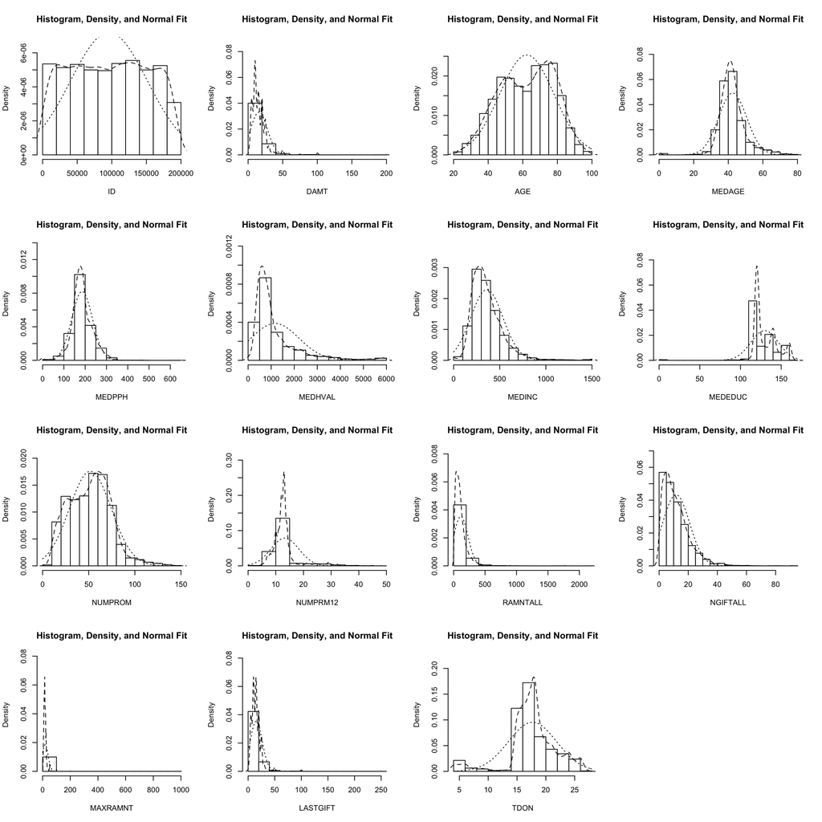

```r
library(plyr)
library(psych)
multi.hist(charity[,sapply(charity, is.numeric)])
```

### 3. Exploratory Data Analysis (EDA)

We now carry out some exploratory data analysis to look for interesting relationships in the data.

1. First, lets use R to perform EDA for the dataset provided. The response for the regression problem is DAMT. Note that ID is for identification purposes only and is not to be used as a predictor, so we remove it here:

```r
df = charity[,-1]
names(df)
```

```
##  [1] "DONR"     "DAMT"     "AGE"      "HOME"     "HINC"     "GENDER"
##  [7] "MEDAGE"   "MEDPPH"   "MEDHVAL"  "MEDINC"   "MEDEDUC"  "NUMPROM"
## [13] "NUMPRM12" "RAMNTALL" "NGIFTALL" "MAXRAMNT" "LASTGIFT" "TDON"
## [19] "RFA_97"   "RFA_96"
```

```r
# create new df (df.num) with numeric and integer values only
df.num = df[,sapply(df, class) %in% c("numeric", "integer") ]

# calculate the correlations between each variable and DAMT
apply(df.num,2, function(col)cor(col, df.num$DAMT))
```

```
##         DAMT          AGE       MEDAGE       MEDPPH      MEDHVAL
##  1.000000000 -0.038045995 -0.007955250  0.006007078  0.117187497
##       MEDINC      MEDEDUC      NUMPROM     NUMPRM12     RAMNTALL
##  0.116075894  0.098541657 -0.062017398  0.053085624  0.241017763
##     NGIFTALL     MAXRAMNT     LASTGIFT         TDON
## -0.228635643  0.413655229  0.723565585  0.106194760
```

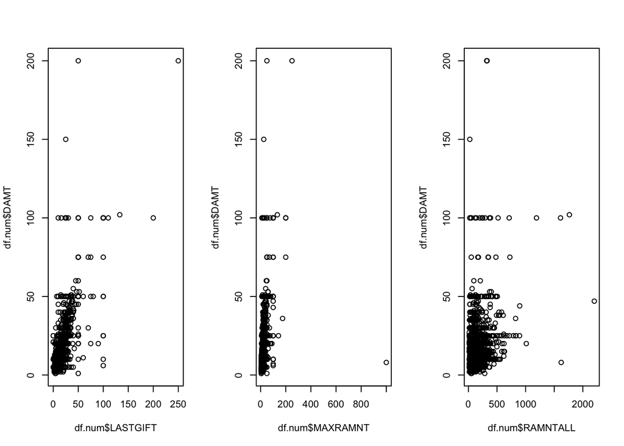

```r
# build scatterplots between numeric variables
par(mfrow=c(1,3))
plot(df.num$LASTGIFT, df.num$DAMT)
plot(df.num$MAXRAMNT, df.num$DAMT)
plot(df.num$RAMNTALL, df.num$DAMT)
```

Let’s also include boxplots of the categorical variables to see which of those may be predictive. From the boxplots of the categorical variables against DAMT we can see that there are some extreme values for each variable. However, median values for HOME and HINC are quite similar, whereas median donation values for RFA_96 and RFA_97 vary across each of the factors showing some potential to be good predictors. There will be an opportunity to break out the RFA statuses in the next section. R code and output below.

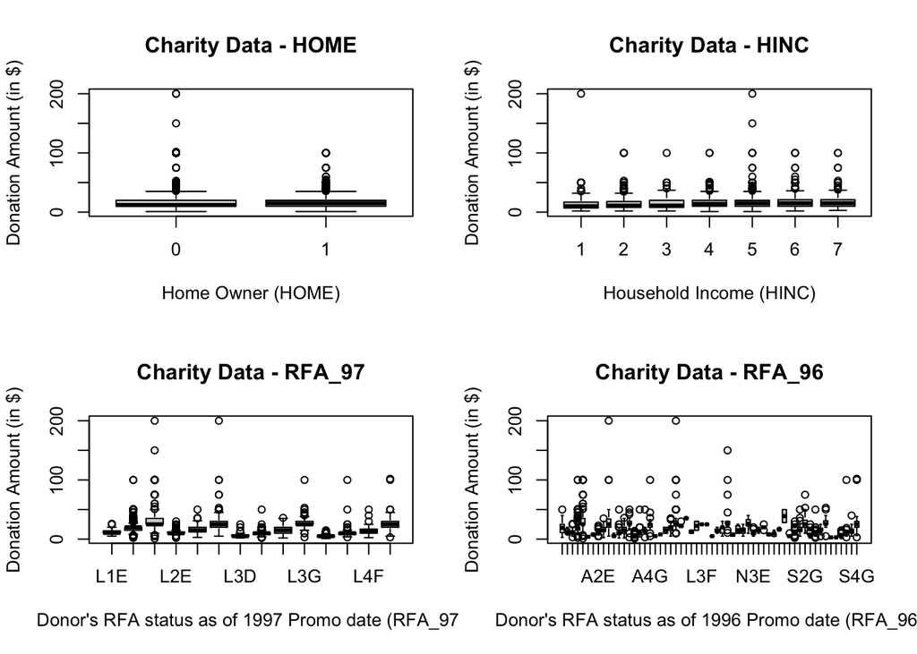

```r
par(mfrow=c(2,2))
boxplot(DAMT~HOME, data=charity, col='lightgray',main="Charity Data - HOME",
        xlab="Home Owner (HOME)",
        ylab="Donation Amount (in $)")

boxplot(DAMT~HINC, data=charity, col='lightgray',main="Charity Data - HINC",
        xlab="Household Income (HINC)",
        ylab="Donation Amount (in $)")

boxplot(DAMT~RFA_97, data=charity, col='lightgray',main="Charity Data - RFA_97",
        xlab="Donor's RFA status as of 1997 Promo date (RFA_97)",
        ylab="Donation Amount (in $)")

boxplot(DAMT~RFA_96, data=charity, col='lightgray',main="Charity Data - RFA_96",
        xlab="Donor's RFA status as of 1996 Promo date (RFA_96)",
        ylab="Donation Amount (in $)")
```

### 4. Data Preparation

There are several types of data preparation to consider: addressing missing values, transforming variables, deriving new variables, and re-categorizing categorical variables. You should consider performing some or all of these forms of data preparation.

Briefly describe any data preparation steps that you take. Short sentences and bullet points are fine. From reading your response, I should understand what changes have been made to the data from its raw form (in the CSV file) to the form that you use to train your models. Items to address include:

1. How did you handle missing values? The missing values are found in the household income (HINC) variable. Given that the box plots showed very similar levels of donations across each of the seven incomes levels I decided to remove the HINC function from the analysis.

```r
df1 = charity[,-6]
names(df1)
```

```
##  [1] "ID"       "DONR"     "DAMT"     "AGE"      "HOME"     "GENDER"
##  [7] "MEDAGE"   "MEDPPH"   "MEDHVAL"  "MEDINC"   "MEDEDUC"  "NUMPROM"
## [13] "NUMPRM12" "RAMNTALL" "NGIFTALL" "MAXRAMNT" "LASTGIFT" "TDON"
## [19] "RFA_97"   "RFA_96"
```

2. Are there any derived or transformed variables that you added to the dataset?

Although many of the variables have extreme values, I decided to work with the log of MAXRAMNT to reign in the outlier values. Although the value is an outlier, it appears to be a valid contribution. By taking the log of MAXRAMNT we reign in the distribution of values across the x-axis, as can be seen from the output below.

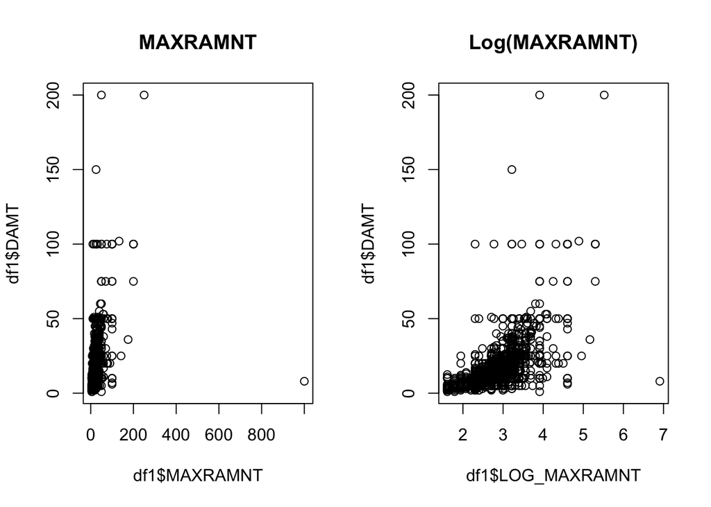

```r
par(mfrow=c(1,2))
df1$LOG_MAXRAMNT = log(df1$MAXRAMNT)
plot(df1$MAXRAMNT,df1$DAMT, main='MAXRAMNT')
plot(df1$LOG_MAXRAMNT,df1$DAMT, main='Log(MAXRAMNT)')
```

3. Did you perform any re-categorization of categorical variables? Given that there is a lot of information compiled into the three letter codes of RFA_96 and RFA_97 for RECENCY, FREQUENCY, and AMOUNT, we break each of the two variables out into five new variables. Note that RECENCY_97 is not included as an additional variable because all donors in this column are ‘L’, or lapsing donors.

```r
#df1$RECENCY_97   = substr(RFA_97,1,1)   #removed as only 1 factor found.
df1$FREQUENCY_97 = substr(RFA_97,2,2)
df1$AMOUNT_97    = substr(RFA_97,3,3)

df1$RECENCY_96   = substr(RFA_96,1,1)
df1$FREQUENCY_96 = substr(RFA_96,2,2)
df1$AMOUNT_96    = substr(RFA_96,3,3)

names(df1)
```

```
##  [1] "ID"           "DONR"         "DAMT"         "AGE"
##  [5] "HOME"         "GENDER"       "MEDAGE"       "MEDPPH"
##  [9] "MEDHVAL"      "MEDINC"       "MEDEDUC"      "NUMPROM"
## [13] "NUMPRM12"     "RAMNTALL"     "NGIFTALL"     "MAXRAMNT"
## [17] "LASTGIFT"     "TDON"         "RFA_97"       "RFA_96"
## [21] "LOG_MAXRAMNT" "FREQUENCY_97" "AMOUNT_97"    "RECENCY_96"
## [25] "FREQUENCY_96" "AMOUNT_96"
```

```r
df1 = df1[,c(-19,-20)]
names(df1)
```

```
##  [1] "ID"           "DONR"         "DAMT"         "AGE"
##  [5] "HOME"         "GENDER"       "MEDAGE"       "MEDPPH"
##  [9] "MEDHVAL"      "MEDINC"       "MEDEDUC"      "NUMPROM"
## [13] "NUMPRM12"     "RAMNTALL"     "NGIFTALL"     "MAXRAMNT"
## [17] "LASTGIFT"     "TDON"         "LOG_MAXRAMNT" "FREQUENCY_97"
## [21] "AMOUNT_97"    "RECENCY_96"   "FREQUENCY_96" "AMOUNT_96"
```

### 5. Dataset Partitioning

For this assignment, you will employ a hold-out test dataset for model validation and selection.

1. Hold-Out Test Set The first step you should take is to sample 25% of the observations in the dataset to form a hold-out test set. This data will be referred to as the Regression Test Set (or simply the Test Set for the remainder of this document). Report the number of observations and the distribution of response values in the Test Set. The data in the Test Set should not be used until Exercise 7 of this assignment.
2. Training Set The remaining 75% of the observations will be referred to as the Regression Training Set (or simply the Training Set for the remainder of this document). Report the number of observations and the distribution of response values in the Training Set.

```r
dim(df1) # 3684 x 24
```

```
## [1] 3684   24
```

```r
names(df1)
```

```
##  [1] "ID"           "DONR"         "DAMT"         "AGE"
##  [5] "HOME"         "GENDER"       "MEDAGE"       "MEDPPH"
##  [9] "MEDHVAL"      "MEDINC"       "MEDEDUC"      "NUMPROM"
## [13] "NUMPRM12"     "RAMNTALL"     "NGIFTALL"     "MAXRAMNT"
## [17] "LASTGIFT"     "TDON"         "LOG_MAXRAMNT" "FREQUENCY_97"
## [21] "AMOUNT_97"    "RECENCY_96"   "FREQUENCY_96" "AMOUNT_96"
```

```r
df1=df1[,-c(1,2,6)]  # removes ID and DONR
names(df1)
```

```
##  [1] "DAMT"         "AGE"          "HOME"         "MEDAGE"
##  [5] "MEDPPH"       "MEDHVAL"      "MEDINC"       "MEDEDUC"
##  [9] "NUMPROM"      "NUMPRM12"     "RAMNTALL"     "NGIFTALL"
## [13] "MAXRAMNT"     "LASTGIFT"     "TDON"         "LOG_MAXRAMNT"
## [17] "FREQUENCY_97" "AMOUNT_97"    "RECENCY_96"   "FREQUENCY_96"
## [21] "AMOUNT_96"
```

```r
smp.size = floor(0.75 * nrow(df1))

set.seed(1)
train = sample(seq_len(nrow(df1)), size = smp.size)
test = -train

ch.train = df1[train,]
ch.test = df1[-train,]

dim(ch.train)
```

```
## [1] 2763   21
```

```r
summary(ch.train)
```

```
##       DAMT             AGE        HOME         MEDAGE          MEDPPH
##  Min.   :  1.00   Min.   :20.00   0: 912   Min.   : 0.00   Min.   :  0.0
##  1st Qu.: 10.00   1st Qu.:50.00   1:1851   1st Qu.:38.00   1st Qu.:158.0
##  Median : 14.00   Median :63.00            Median :42.00   Median :180.0
##  Mean   : 15.94   Mean   :62.27            Mean   :42.45   Mean   :185.3
##  3rd Qu.: 20.00   3rd Qu.:75.00            3rd Qu.:45.00   3rd Qu.:210.0
##  Max.   :200.00   Max.   :98.00            Max.   :79.00   Max.   :472.0
##     MEDHVAL         MEDINC          MEDEDUC         NUMPROM
##  Min.   :   0   Min.   :   0.0   Min.   :  0.0   Min.   :  9.00
##  1st Qu.: 552   1st Qu.: 246.0   1st Qu.:120.0   1st Qu.: 33.00
##  Median : 819   Median : 324.0   Median :121.0   Median : 52.00
##  Mean   :1164   Mean   : 360.0   Mean   :129.7   Mean   : 51.19
##  3rd Qu.:1374   3rd Qu.: 436.5   3rd Qu.:140.0   3rd Qu.: 67.00
##  Max.   :5975   Max.   :1500.0   Max.   :170.0   Max.   :144.00
##     NUMPRM12        RAMNTALL       NGIFTALL        MAXRAMNT
##  Min.   : 4.00   Min.   :  15   Min.   : 1.00   Min.   :   5.00
##  1st Qu.:11.00   1st Qu.:  49   1st Qu.: 5.00   1st Qu.:  11.00
##  Median :13.00   Median :  87   Median : 9.00   Median :  15.00
##  Mean   :13.13   Mean   : 114   Mean   :11.48   Mean   :  18.56
##  3rd Qu.:14.00   3rd Qu.: 141   3rd Qu.:16.00   3rd Qu.:  20.00
##  Max.   :48.00   Max.   :2200   Max.   :91.00   Max.   :1000.00
##     LASTGIFT           TDON        LOG_MAXRAMNT   FREQUENCY_97
##  Min.   :  0.00   Min.   : 4.00   Min.   :1.609   Length:2763
##  1st Qu.: 10.00   1st Qu.:16.00   1st Qu.:2.398   Class :character
##  Median : 15.00   Median :18.00   Median :2.708   Mode  :character
##  Mean   : 15.48   Mean   :17.78   Mean   :2.762
##  3rd Qu.: 20.00   3rd Qu.:20.00   3rd Qu.:2.996
##  Max.   :250.00   Max.   :27.00   Max.   :6.908
##   AMOUNT_97          RECENCY_96        FREQUENCY_96
##  Length:2763        Length:2763        Length:2763
##  Class :character   Class :character   Class :character
##  Mode  :character   Mode  :character   Mode  :character
##
##
##
##   AMOUNT_96
##  Length:2763
##  Class :character
##  Mode  :character
##
##
##
```

```r
dim(ch.test)
```

```
## [1] 921  21
```

```r
summary(ch.test)
```

```
##       DAMT             AGE        HOME        MEDAGE          MEDPPH
##  Min.   :  1.00   Min.   :25.00   0:300   Min.   : 0.00   Min.   :  0.0
##  1st Qu.: 10.00   1st Qu.:50.00   1:621   1st Qu.:38.00   1st Qu.:158.0
##  Median : 12.50   Median :64.00           Median :42.00   Median :181.0
##  Mean   : 15.05   Mean   :62.51           Mean   :42.77   Mean   :186.5
##  3rd Qu.: 20.00   3rd Qu.:75.00           3rd Qu.:46.00   3rd Qu.:213.0
##  Max.   :200.00   Max.   :98.00           Max.   :76.00   Max.   :650.0
##     MEDHVAL         MEDINC          MEDEDUC         NUMPROM
##  Min.   :   0   Min.   :   0.0   Min.   :  0.0   Min.   : 11.00
##  1st Qu.: 565   1st Qu.: 243.0   1st Qu.:120.0   1st Qu.: 35.00
##  Median : 822   Median : 330.0   Median :121.0   Median : 55.00
##  Mean   :1183   Mean   : 361.4   Mean   :129.3   Mean   : 53.29
##  3rd Qu.:1362   3rd Qu.: 428.0   3rd Qu.:140.0   3rd Qu.: 68.00
##  Max.   :5980   Max.   :1500.0   Max.   :170.0   Max.   :147.00
##     NUMPRM12        RAMNTALL        NGIFTALL        MAXRAMNT
##  Min.   : 3.00   Min.   : 15.0   Min.   : 1.00   Min.   :  5.00
##  1st Qu.:11.00   1st Qu.: 53.0   1st Qu.: 6.00   1st Qu.: 10.00
##  Median :13.00   Median : 94.0   Median :11.00   Median : 15.00
##  Mean   :13.73   Mean   :118.2   Mean   :12.18   Mean   : 17.46
##  3rd Qu.:14.00   3rd Qu.:149.0   3rd Qu.:17.00   3rd Qu.: 20.00
##  Max.   :45.00   Max.   :897.0   Max.   :77.00   Max.   :200.00
##     LASTGIFT           TDON        LOG_MAXRAMNT   FREQUENCY_97
##  Min.   :  0.00   Min.   : 4.00   Min.   :1.609   Length:921
##  1st Qu.: 10.00   1st Qu.:16.00   1st Qu.:2.303   Class :character
##  Median : 14.00   Median :18.00   Median :2.708   Mode  :character
##  Mean   : 14.41   Mean   :17.38   Mean   :2.712
##  3rd Qu.: 20.00   3rd Qu.:20.00   3rd Qu.:2.996
##  Max.   :100.00   Max.   :26.00   Max.   :5.298
##   AMOUNT_97          RECENCY_96        FREQUENCY_96
##  Length:921         Length:921         Length:921
##  Class :character   Class :character   Class :character
##  Mode  :character   Mode  :character   Mode  :character
##
##
##
##   AMOUNT_96
##  Length:921
##  Class :character
##  Mode  :character
##
##
##
```

### 6. Model Fitting

Use R to develop various models for the response variable DAMT. The variables ID and DONR are not to be used as predictors. Fit at least one model from each of the following four categories. Each model should be fit to the Training Set data only.

#### Simple Linear Regression Model

1. Simple linear regression model:

DAMT = B0 + B1*LASTGIFT + e

For the first model we run a simple linear regression model using LASTGIFT as the single predictor since this was the variable that was most correlated to DAMT with an r-value = 0.72. The LASTGIFT variable is significant and has an R^2 value of 0.56

```r
fit1 = lm(DAMT~LASTGIFT,ch.train)
summary(fit1)
```

```
##
## Call:
## lm(formula = DAMT ~ LASTGIFT, data = ch.train)
##
## Residuals:
##     Min      1Q  Median      3Q     Max
## -75.690  -2.788  -0.567   1.767 126.654
##
## Coefficients:
##             Estimate Std. Error t value Pr(>|t|)
## (Intercept)  3.89802    0.25444   15.32   <2e-16 ***
## LASTGIFT     0.77792    0.01311   59.36   <2e-16 ***
## ---
## Signif. codes:  0 '***' 0.001 '**' 0.01 '*' 0.05 '.' 0.1 ' ' 1
##
## Residual standard error: 8.076 on 2761 degrees of freedom
## Multiple R-squared:  0.5607, Adjusted R-squared:  0.5605
## F-statistic:  3524 on 1 and 2761 DF,  p-value: < 2.2e-16
```

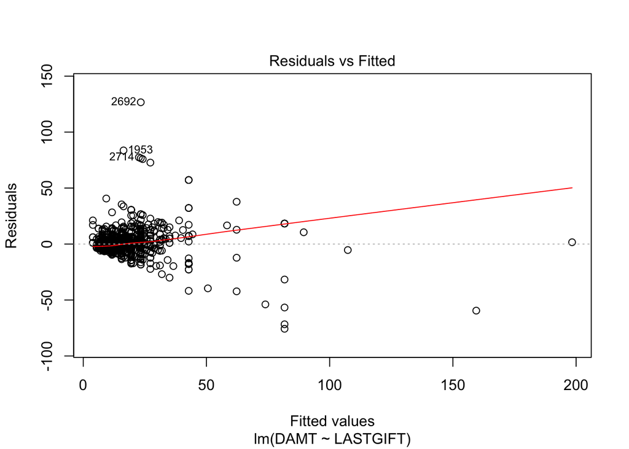

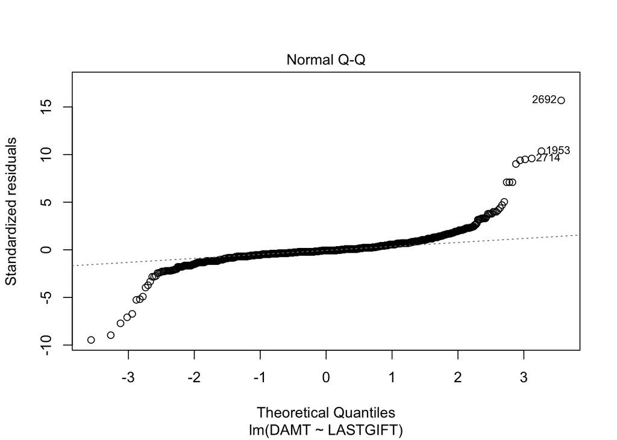

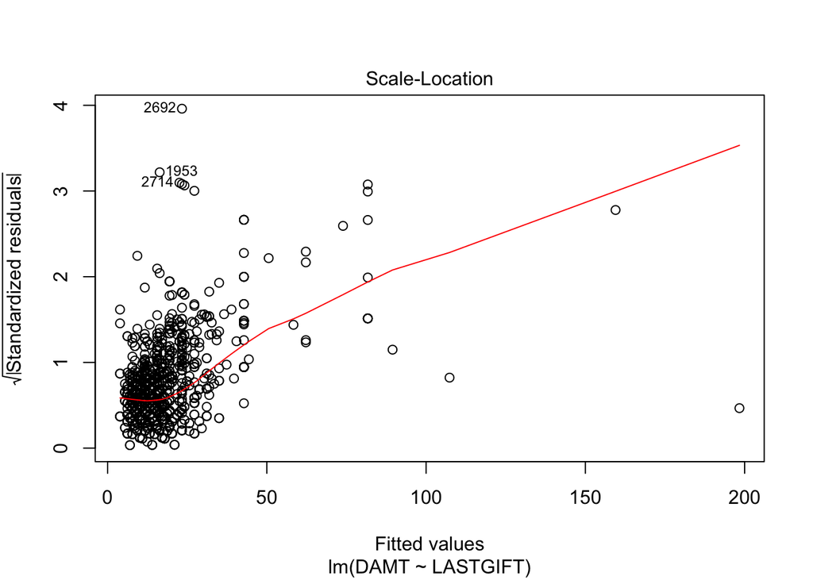

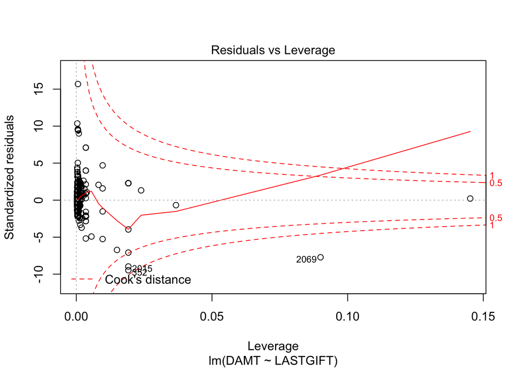

```r
plot(fit1)
```

2. Multiple linear regression (ISLR Section 3.1) or multiple linear regression with subset selection (ISLR Section 6.1)